# 03_analysis

Arianna Benedetti

12/9/2016

In this code, I will load the cleaned datasets into R, run correlations between CEO-to-worker compensation ratio and several ratings variables, visualize the significant variables with histograms and scatterplots showing the relationships, and run final regressions controlling for several potential confounds.

## Loading Datasets For Analysis

```r
###Load Data###
CEO.outliers <-read.csv("~/Box Sync/Berkeley/Fall 2016/PolSci239T/PS239T-final-project/Data/03_CEO_outliers.csv", header=T) #Load outlier data for graphing
CEO.analyze <-read.csv("~/Box Sync/Berkeley/Fall 2016/PolSci239T/PS239T-final-project/Data/04_CEO_analyze.csv", header=T) #Load Analysis Data
```

## Correlation matrix

Running a correlation matrix between CEO-to-worker comepnsation ratios and several dependent variables of interest. (typically I’d do this after visualizing, but doing it early to cut down on variables to visualize.)

```r
#I like using the Hmisc rcorr to run correlations because
#you can easily load the values into a csv
CEO.correlations <- rcorr(as.matrix(CEO.analyze[c("ratio","overall", "culturevalues", "wlb",
                                                  "careerops", "comp", "srleadership",
                                                  "ceopctApprove", "rectofriend"
                                        )]), type="pearson")
objects(CEO.correlations) #Hmisc correlations breaks down the objects very nicely
```

```
## [1] "n" "P" "r"
```

```r
#Primarily interested in relationship b/t CEO ratio & other variables
#so lets look at just that
round(cbind(CEO.correlations$r[,1], CEO.correlations$P[,1]),2)
```

```
##                [,1] [,2]
## ratio          1.00   NA
## overall       -0.08 0.14
## culturevalues -0.06 0.29
## wlb           -0.20 0.00
## careerops     -0.02 0.75
## comp          -0.17 0.00
## srleadership  -0.08 0.14
## ceopctApprove -0.06 0.24
## rectofriend   -0.08 0.13
```

```r
#Okay, so it appears there is a significant relationship b/t ratio and ratings of work/life balance
#and ratio and ratings of compensation and benefits
```

## Visualizing the variables

Now that we’re seeing a relationship between CEO ratio and work life balance and compensation and benefits ratings, let’s look at the univariate density plots of each of these.

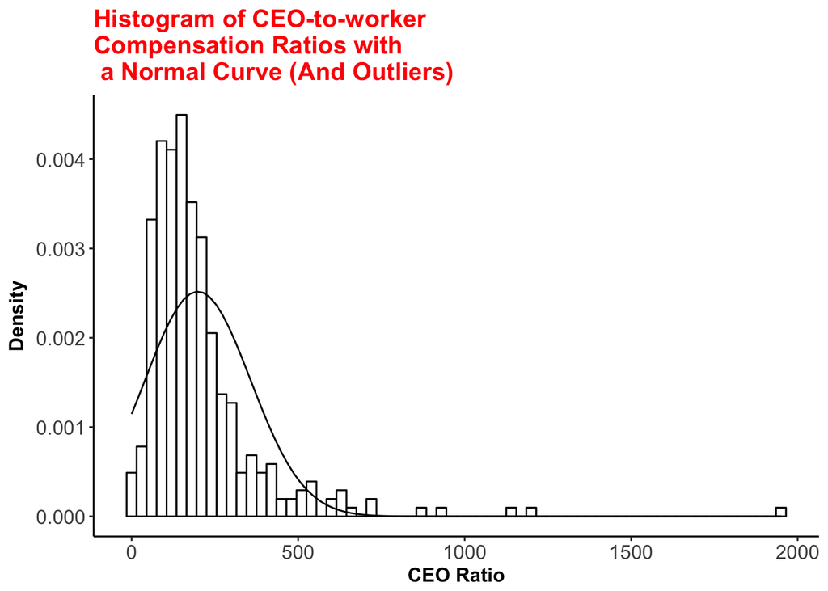

```r
##CEO Ratio With outliers
Ratioplot.outliers<- ggplot(CEO.outliers, aes(ratio)) +
  geom_histogram(aes(y=..density..), binwidth = 30, colour="black", fill="white") +
  stat_function(fun=dnorm, args=list(mean=mean(CEO.analyze$ratio, na.rm=T), sd=sd(CEO.analyze$ratio, na.rm=T))) +
  xlab("CEO Ratio") +
  ylab("Density") +
  theme_classic() +
  ggtitle("Histogram of CEO-to-worker\nCompensation Ratios with\n a Normal Curve (And Outliers)") +
  theme(axis.title.x = element_text(face="bold", size=12), axis.title.y = element_text(face="bold",size=12),
        axis.text.x = element_text(size=12), axis.text.y = element_text(size=12),
        axis.line.x = element_line(size = .5), axis.line.y = element_line(size = .5),
        plot.title = element_text(size=15, face="bold", color="red"),
        legend.position="none")
Ratioplot.outliers
```

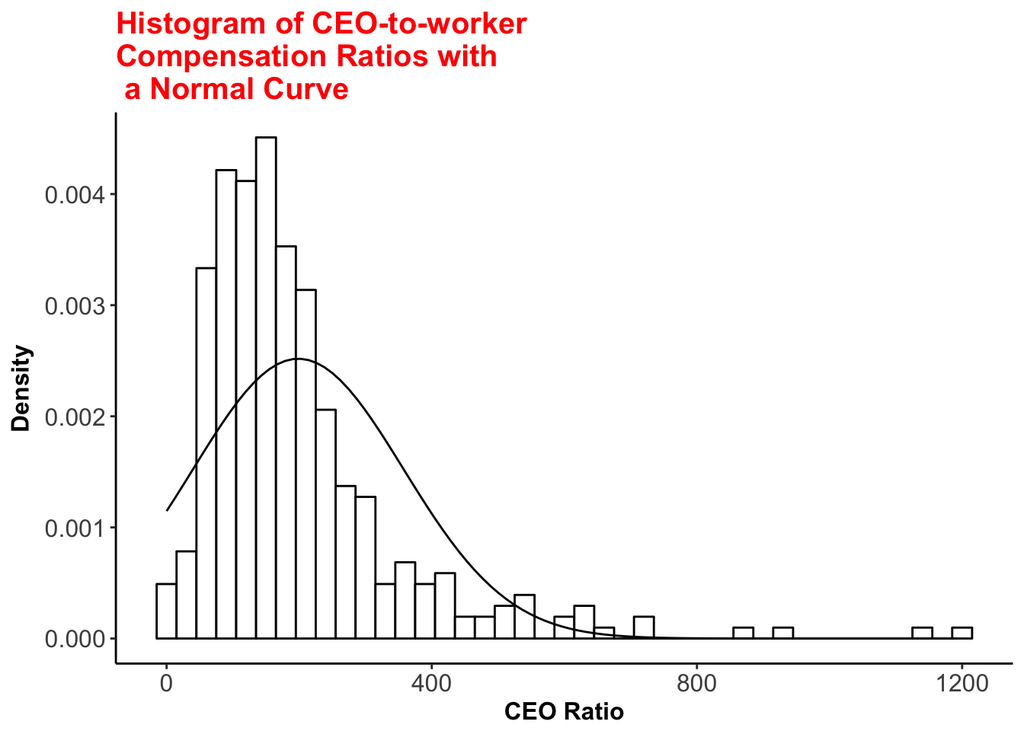

```r
#CEO Ratio Without outliers
Ratioplot.nooutliers<-ggplot(CEO.analyze, aes(ratio)) +
  geom_histogram(aes(y=..density..), binwidth = 30, colour="black", fill="white") +
  stat_function(fun=dnorm, args=list(mean=mean(CEO.analyze$ratio, na.rm=T), sd=sd(CEO.analyze$ratio, na.rm=T))) +
  xlab("CEO Ratio") +
  ylab("Density") +
  theme_classic() +
  ggtitle("Histogram of CEO-to-worker\nCompensation Ratios with\n a Normal Curve") +
  theme(axis.title.x = element_text(face="bold", size=12), axis.title.y = element_text(face="bold",size=12),
        axis.text.x = element_text(size=12), axis.text.y = element_text(size=12),
        axis.line.x = element_line(size = .5), axis.line.y = element_line(size = .5),
        plot.title = element_text(size=15, face="bold", color="red"),
        legend.position="none")
Ratioplot.nooutliers
```

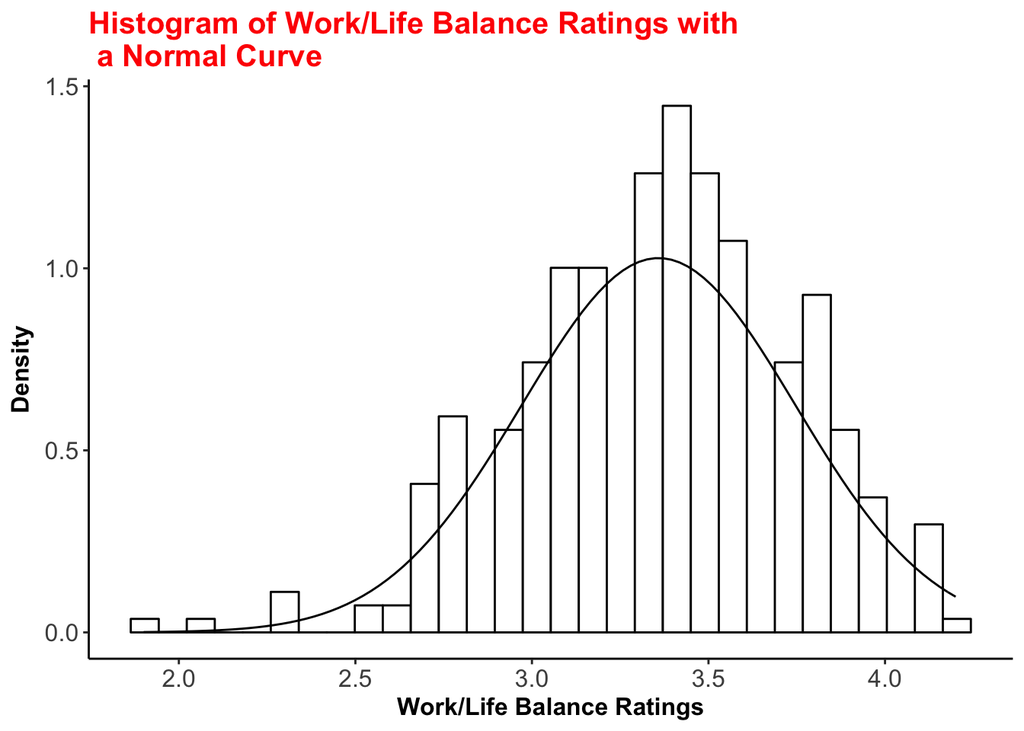

```r
#Not very normal even once outliers are removed, but going to keep as-is instead of log-transform for analyses (same results either way, I've checked)

#Now checking work/life balance
WLBplot <- ggplot(CEO.analyze, aes(wlb)) +
  geom_histogram(aes(y=..density..), colour="black", fill="white") +
  stat_function(fun=dnorm, args=list(mean=mean(CEO.analyze$wlb, na.rm=T), sd=sd(CEO.analyze$wlb, na.rm=T))) +
  xlab("Work/Life Balance Ratings") +
  ylab("Density") +
  theme_classic() +
  ggtitle("Histogram of Work/Life Balance Ratings with\n a Normal Curve") +
  theme(axis.title.x = element_text(face="bold", size=12), axis.title.y = element_text(face="bold",size=12),
        axis.text.x = element_text(size=12), axis.text.y = element_text(size=12),
        axis.line.x = element_line(size = .5), axis.line.y = element_line(size = .5),
        plot.title = element_text(size=15, face="bold", color="red"))
WLBplot
```

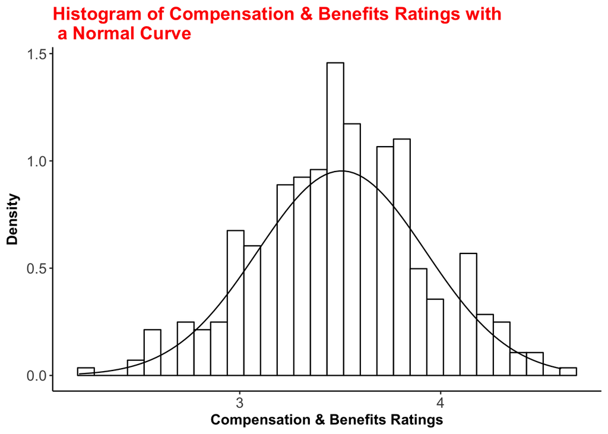

```r
#And checking compensation
Compplot<- ggplot(CEO.analyze, aes(comp)) +
  geom_histogram(aes(y=..density..), colour="black", fill="white") +
  stat_function(fun=dnorm, args=list(mean=mean(CEO.analyze$comp, na.rm=T), sd=sd(CEO.analyze$comp, na.rm=T))) +
  xlab("Compensation & Benefits Ratings") +
  ylab("Density") +
  theme_classic() +
  ggtitle("Histogram of Compensation & Benefits Ratings with\n a Normal Curve") +
  theme(axis.title.x = element_text(face="bold", size=12), axis.title.y = element_text(face="bold",size=12),
        axis.text.x = element_text(size=12), axis.text.y = element_text(size=12),
        axis.line.x = element_line(size = .5), axis.line.y = element_line(size = .5),
        plot.title = element_text(size=15, face="bold", color="red"),
        legend.position="none")
Compplot
```

```r
#Both look very normal
```

Now let’s take a look at the bivariate scatterplots with a regression line of CEO ratio and work/life balance as well as CEO ratio and compensation and benefits ratings.

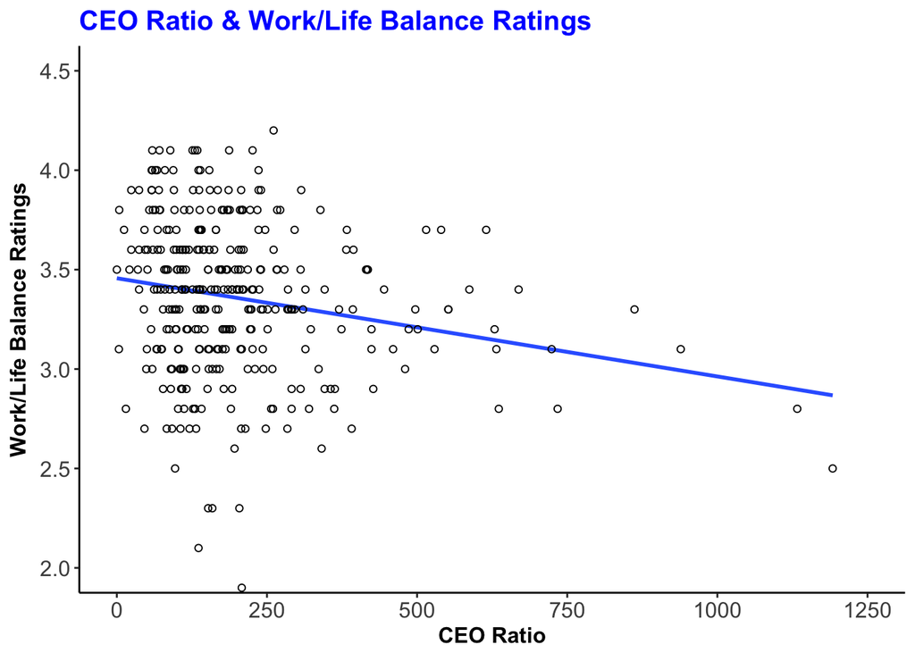

```r
#Work/life balance
Ratio.WLB.plot <- ggplot(CEO.analyze, aes(x=ratio, y=wlb)) +
  geom_smooth(method=lm, se=F) +
  geom_point(shape=1) +
  xlab("CEO Ratio") +
  ylab("Work/Life Balance Ratings") +
  coord_cartesian(xlim=c(0,1250), ylim=c(2,4.5)) +
  scale_x_continuous(breaks=seq(0, 1250, 250)) +
  scale_y_continuous(breaks=seq(2, 4.5, .5)) +
  theme_classic() +
  ggtitle("CEO Ratio & Work/Life Balance Ratings") +
  theme(axis.title.x = element_text(face="bold", size=12), axis.title.y = element_text(face="bold",size=12),
        axis.text.x = element_text(size=12), axis.text.y = element_text(size=12),
        axis.line.x = element_line(size = .5), axis.line.y = element_line(size = .5),
        plot.title = element_text(size=15, face="bold", color="blue"),
        legend.position="none")
Ratio.WLB.plot
```

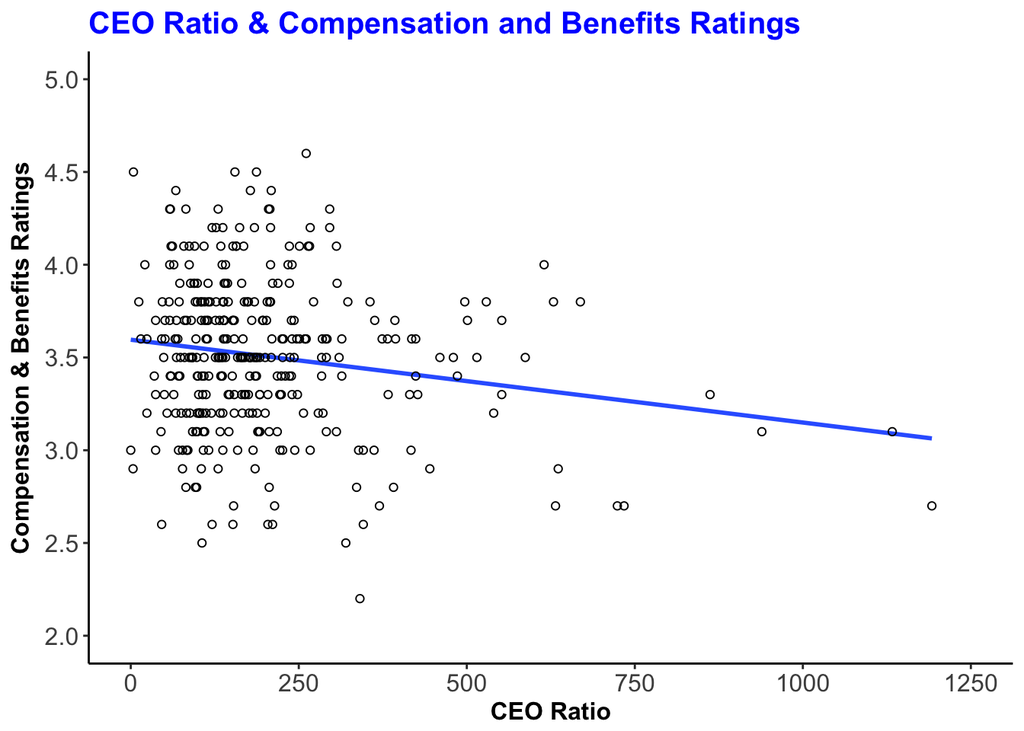

```r
#Compensation and Benefits
Ratio.Comp.plot <- ggplot(CEO.analyze, aes(x=ratio, y=comp)) +
  geom_smooth(method=lm, se=F) +
  geom_point(shape=1) +
  xlab("CEO Ratio") +
  ylab("Compensation & Benefits Ratings") +
  coord_cartesian(xlim=c(0,1250), ylim=c(2,5)) +
  scale_x_continuous(breaks=seq(0, 1250, 250)) +
  scale_y_continuous(breaks=seq(2, 5, .5)) +
  theme_classic() +
  ggtitle("CEO Ratio & Compensation and Benefits Ratings") +
  theme(axis.title.x = element_text(face="bold", size=12), axis.title.y = element_text(face="bold",size=12),
        axis.text.x = element_text(size=12), axis.text.y = element_text(size=12),
        axis.line.x = element_line(size = .5), axis.line.y = element_line(size = .5),
        plot.title = element_text(size=15, face="bold", color="blue"),
        legend.position="none")
Ratio.Comp.plot
```

## Regressions controlling for other variables

It appears that there is a negative relationship between CEO-to-worker compensation ratios and workers’ work/life balance and compensation & benfits ratings. Let’s see if this relationship is still significant when controlling for company size, company ratings, and net company income (as of Quarter 4, 2015)

```r
#check to make sure these function as we want them in the analyses
class(CEO.analyze$size)
```

```
## [1] "integer"
```

```r
class(CEO.analyze$profits)
```

```
## [1] "integer"
```

```r
class(CEO.analyze$numberOfRatings)
```

```
## [1] "integer"
```

```r
#These are categorized correctly...let's check whether the relationships hold controlling for size, profits, and # of ratings

wlb.reg <- summary(lm(scale(wlb) ~ scale(ratio) + scale(size) + scale(profits) + scale(numberOfRatings), data=CEO.analyze))
wlb.reg  #ratio still significantly negatively predicts work/life balance ratings
```

```
##
## Call:
## lm(formula = scale(wlb) ~ scale(ratio) + scale(size) + scale(profits) +
##     scale(numberOfRatings), data = CEO.analyze)
##
## Residuals:
##     Min      1Q  Median      3Q     Max
## -3.7492 -0.6646  0.0568  0.6738  2.0272
##
## Coefficients:
##                        Estimate Std. Error t value Pr(>|t|)
## (Intercept)             0.01154    0.05385   0.214  0.83039
## scale(ratio)           -0.17967    0.06286  -2.858  0.00453 **
## scale(size)            -0.09576    0.07281  -1.315  0.18936
## scale(profits)         -0.05795    0.05957  -0.973  0.33143
## scale(numberOfRatings)  0.07660    0.07488   1.023  0.30707
## ---
## Signif. codes:  0 '***' 0.001 '**' 0.01 '*' 0.05 '.' 0.1 ' ' 1
##
## Residual standard error: 0.9827 on 328 degrees of freedom
##   (7 observations deleted due to missingness)
## Multiple R-squared:  0.04958,    Adjusted R-squared:  0.03799
## F-statistic: 4.278 on 4 and 328 DF,  p-value: 0.002181
```

```r
comp.reg <- summary(lm(scale(comp) ~ scale(ratio) + scale(size) + scale(profits) + scale(numberOfRatings), data=CEO.analyze))
comp.reg #ratio still significantly negatively predicts compensation/benefits ratings
```

```
##
## Call:
## lm(formula = scale(comp) ~ scale(ratio) + scale(size) + scale(profits) +
##     scale(numberOfRatings), data = CEO.analyze)
##
## Residuals:
##      Min       1Q   Median       3Q      Max
## -2.97492 -0.66017  0.05193  0.59909  2.93670
##
## Coefficients:
##                         Estimate Std. Error t value Pr(>|t|)
## (Intercept)             0.016065   0.054225   0.296   0.7672
## scale(ratio)           -0.147026   0.063292  -2.323   0.0208 *
## scale(size)            -0.006797   0.073314  -0.093   0.9262
## scale(profits)          0.093380   0.059987   1.557   0.1205
## scale(numberOfRatings) -0.091723   0.075399  -1.217   0.2247
## ---
## Signif. codes:  0 '***' 0.001 '**' 0.01 '*' 0.05 '.' 0.1 ' ' 1
##
## Residual standard error: 0.9895 on 328 degrees of freedom
##   (7 observations deleted due to missingness)
## Multiple R-squared:  0.03976,    Adjusted R-squared:  0.02805
## F-statistic: 3.395 on 4 and 328 DF,  p-value: 0.009698
```